# IODS course project

# Chapter 4

## Clustering and classification

- Loading the Boston data from the MASS package.

```r
library(MASS)

# load the data
data("Boston")

# explore the dataset
dim(Boston)
```

```
## [1] 506  14
```

```r
str(Boston)
```

```
## 'data.frame':    506 obs. of  14 variables:
##  $ crim   : num  0.00632 0.02731 0.02729 0.03237 0.06905 ...
##  $ zn     : num  18 0 0 0 0 0 12.5 12.5 12.5 12.5 ...
##  $ indus  : num  2.31 7.07 7.07 2.18 2.18 2.18 7.87 7.87 7.87 7.87 ...
##  $ chas   : int  0 0 0 0 0 0 0 0 0 0 ...
##  $ nox    : num  0.538 0.469 0.469 0.458 0.458 0.458 0.524 0.524 0.524 0.524 ...
##  $ rm     : num  6.58 6.42 7.18 7 7.15 ...
##  $ age    : num  65.2 78.9 61.1 45.8 54.2 58.7 66.6 96.1 100 85.9 ...
##  $ dis    : num  4.09 4.97 4.97 6.06 6.06 ...
##  $ rad    : int  1 2 2 3 3 3 5 5 5 5 ...
##  $ tax    : num  296 242 242 222 222 222 311 311 311 311 ...
##  $ ptratio: num  15.3 17.8 17.8 18.7 18.7 18.7 15.2 15.2 15.2 15.2 ...
##  $ black  : num  397 397 393 395 397 ...
##  $ lstat  : num  4.98 9.14 4.03 2.94 5.33 ...
##  $ medv   : num  24 21.6 34.7 33.4 36.2 28.7 22.9 27.1 16.5 18.9 ...
```

```r
head(Boston)
```

```
##      crim zn indus chas   nox    rm  age    dis rad tax ptratio  black
## 1 0.00632 18  2.31    0 0.538 6.575 65.2 4.0900   1 296    15.3 396.90
## 2 0.02731  0  7.07    0 0.469 6.421 78.9 4.9671   2 242    17.8 396.90
## 3 0.02729  0  7.07    0 0.469 7.185 61.1 4.9671   2 242    17.8 392.83
## 4 0.03237  0  2.18    0 0.458 6.998 45.8 6.0622   3 222    18.7 394.63
## 5 0.06905  0  2.18    0 0.458 7.147 54.2 6.0622   3 222    18.7 396.90
## 6 0.02985  0  2.18    0 0.458 6.430 58.7 6.0622   3 222    18.7 394.12
##   lstat medv
## 1  4.98 24.0
## 2  9.14 21.6
## 3  4.03 34.7
## 4  2.94 33.4
## 5  5.33 36.2
## 6  5.21 28.7
```

The Boston dataset contains housing value information on suburbs of Boston.It contains 506 observations with 14 variables. For each suburb, the data provides information such as per capita crime rate, pupil-teacher ratio, access to highways, etc.

- Overview of the Boston data

```r
head(Boston)
```

```
##      crim zn indus chas   nox    rm  age    dis rad tax ptratio  black
## 1 0.00632 18  2.31    0 0.538 6.575 65.2 4.0900   1 296    15.3 396.90
## 2 0.02731  0  7.07    0 0.469 6.421 78.9 4.9671   2 242    17.8 396.90
## 3 0.02729  0  7.07    0 0.469 7.185 61.1 4.9671   2 242    17.8 392.83
## 4 0.03237  0  2.18    0 0.458 6.998 45.8 6.0622   3 222    18.7 394.63
## 5 0.06905  0  2.18    0 0.458 7.147 54.2 6.0622   3 222    18.7 396.90
## 6 0.02985  0  2.18    0 0.458 6.430 58.7 6.0622   3 222    18.7 394.12
##   lstat medv
## 1  4.98 24.0
## 2  9.14 21.6
## 3  4.03 34.7
## 4  2.94 33.4
## 5  5.33 36.2
## 6  5.21 28.7
```

```r
summary(Boston)
```

```
##       crim                zn             indus            chas
##  Min.   : 0.00632   Min.   :  0.00   Min.   : 0.46   Min.   :0.00000
##  1st Qu.: 0.08204   1st Qu.:  0.00   1st Qu.: 5.19   1st Qu.:0.00000
##  Median : 0.25651   Median :  0.00   Median : 9.69   Median :0.00000
##  Mean   : 3.61352   Mean   : 11.36   Mean   :11.14   Mean   :0.06917
##  3rd Qu.: 3.67708   3rd Qu.: 12.50   3rd Qu.:18.10   3rd Qu.:0.00000
##  Max.   :88.97620   Max.   :100.00   Max.   :27.74   Max.   :1.00000
##       nox               rm             age              dis
##  Min.   :0.3850   Min.   :3.561   Min.   :  2.90   Min.   : 1.130
##  1st Qu.:0.4490   1st Qu.:5.886   1st Qu.: 45.02   1st Qu.: 2.100
##  Median :0.5380   Median :6.208   Median : 77.50   Median : 3.207
##  Mean   :0.5547   Mean   :6.285   Mean   : 68.57   Mean   : 3.795
##  3rd Qu.:0.6240   3rd Qu.:6.623   3rd Qu.: 94.08   3rd Qu.: 5.188
##  Max.   :0.8710   Max.   :8.780   Max.   :100.00   Max.   :12.127
##       rad              tax           ptratio          black
##  Min.   : 1.000   Min.   :187.0   Min.   :12.60   Min.   :  0.32
##  1st Qu.: 4.000   1st Qu.:279.0   1st Qu.:17.40   1st Qu.:375.38
##  Median : 5.000   Median :330.0   Median :19.05   Median :391.44
##  Mean   : 9.549   Mean   :408.2   Mean   :18.46   Mean   :356.67
##  3rd Qu.:24.000   3rd Qu.:666.0   3rd Qu.:20.20   3rd Qu.:396.23
##  Max.   :24.000   Max.   :711.0   Max.   :22.00   Max.   :396.90
##      lstat            medv
##  Min.   : 1.73   Min.   : 5.00
##  1st Qu.: 6.95   1st Qu.:17.02
##  Median :11.36   Median :21.20
##  Mean   :12.65   Mean   :22.53
##  3rd Qu.:16.95   3rd Qu.:25.00
##  Max.   :37.97   Max.   :50.00
```

As we can see from the summary of the variables, the variables have different scales with for example chas variable having a maximum of 1 while tax variable has a maximum of 711. The variables need to be standardized before further analysis.

```r
library(dplyr)
library(corrplot)

cor_matrix<-cor(Boston)

cor_matrix <- cor_matrix %>% round(digits=2)
cor_matrix
```

```
##          crim    zn indus  chas   nox    rm   age   dis   rad   tax
## crim     1.00 -0.20  0.41 -0.06  0.42 -0.22  0.35 -0.38  0.63  0.58
## zn      -0.20  1.00 -0.53 -0.04 -0.52  0.31 -0.57  0.66 -0.31 -0.31
## indus    0.41 -0.53  1.00  0.06  0.76 -0.39  0.64 -0.71  0.60  0.72
## chas    -0.06 -0.04  0.06  1.00  0.09  0.09  0.09 -0.10 -0.01 -0.04
## nox      0.42 -0.52  0.76  0.09  1.00 -0.30  0.73 -0.77  0.61  0.67
## rm      -0.22  0.31 -0.39  0.09 -0.30  1.00 -0.24  0.21 -0.21 -0.29
## age      0.35 -0.57  0.64  0.09  0.73 -0.24  1.00 -0.75  0.46  0.51
## dis     -0.38  0.66 -0.71 -0.10 -0.77  0.21 -0.75  1.00 -0.49 -0.53
## rad      0.63 -0.31  0.60 -0.01  0.61 -0.21  0.46 -0.49  1.00  0.91
## tax      0.58 -0.31  0.72 -0.04  0.67 -0.29  0.51 -0.53  0.91  1.00
## ptratio  0.29 -0.39  0.38 -0.12  0.19 -0.36  0.26 -0.23  0.46  0.46
## black   -0.39  0.18 -0.36  0.05 -0.38  0.13 -0.27  0.29 -0.44 -0.44
## lstat    0.46 -0.41  0.60 -0.05  0.59 -0.61  0.60 -0.50  0.49  0.54
## medv    -0.39  0.36 -0.48  0.18 -0.43  0.70 -0.38  0.25 -0.38 -0.47
##         ptratio black lstat  medv
## crim       0.29 -0.39  0.46 -0.39
## zn        -0.39  0.18 -0.41  0.36
## indus      0.38 -0.36  0.60 -0.48
## chas      -0.12  0.05 -0.05  0.18
## nox        0.19 -0.38  0.59 -0.43
## rm        -0.36  0.13 -0.61  0.70
## age        0.26 -0.27  0.60 -0.38
## dis       -0.23  0.29 -0.50  0.25
## rad        0.46 -0.44  0.49 -0.38
## tax        0.46 -0.44  0.54 -0.47
## ptratio    1.00 -0.18  0.37 -0.51
## black     -0.18  1.00 -0.37  0.33
## lstat      0.37 -0.37  1.00 -0.74
## medv      -0.51  0.33 -0.74  1.00
```

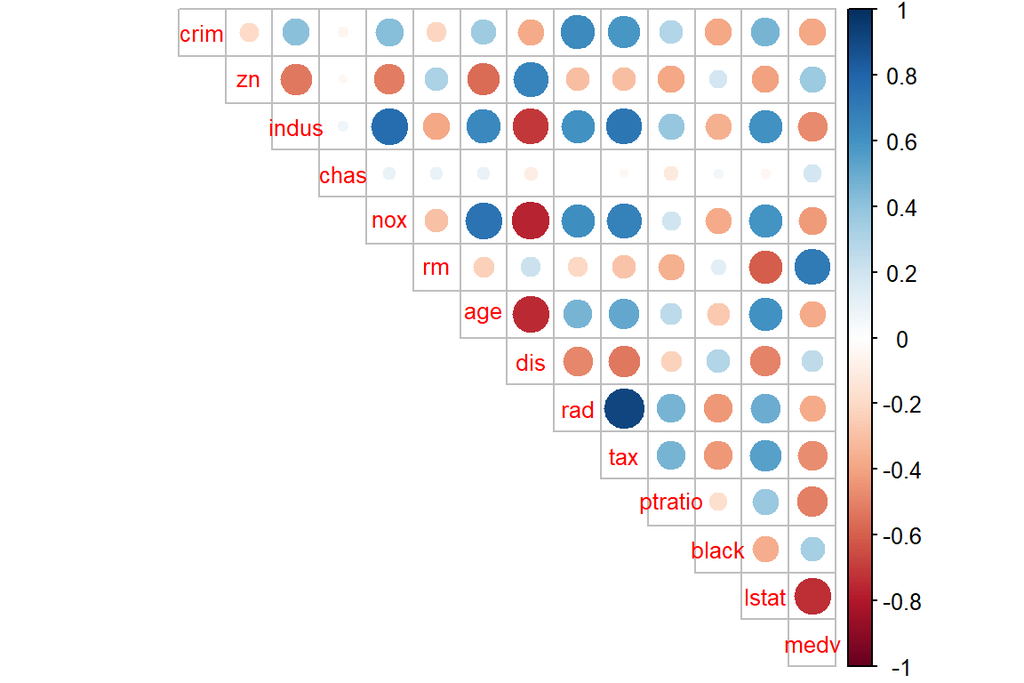

```r
# visualize the correlation matrix
corrplot(cor_matrix, method="circle",type="upper",tl.pos = "d",tl.cex = 0.8)
```

The crime rate seems to have strongest positive correlation to rad (accessibility to radial highways measure) and tax (property tax rate) variables. The relationship between any two variables can be observed from the correlation plot above.

Alternatively, we can use the pairs R function to exlore the relationship between every possible pair of variables in the dataset. We plot pairwise scatter plot for the first 3 variables below.

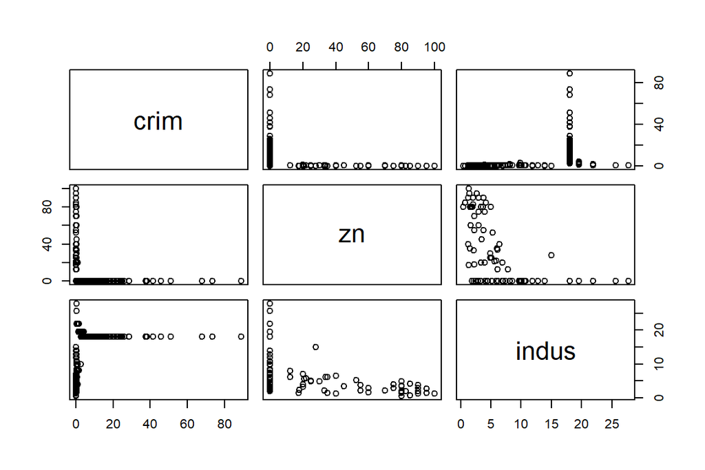

```r
# plot pairwise scatter plot for the first 3 variables
pairs(Boston[1:3])
```

- Scaling the data, and creating a categorical variable for crime rate

```r
# center and standardize variables
boston_scaled <- scale(Boston)

# summaries of the scaled variables
summary(boston_scaled)
```

```
##       crim                 zn               indus
##  Min.   :-0.419367   Min.   :-0.48724   Min.   :-1.5563
##  1st Qu.:-0.410563   1st Qu.:-0.48724   1st Qu.:-0.8668
##  Median :-0.390280   Median :-0.48724   Median :-0.2109
##  Mean   : 0.000000   Mean   : 0.00000   Mean   : 0.0000
##  3rd Qu.: 0.007389   3rd Qu.: 0.04872   3rd Qu.: 1.0150
##  Max.   : 9.924110   Max.   : 3.80047   Max.   : 2.4202
##       chas              nox                rm               age
##  Min.   :-0.2723   Min.   :-1.4644   Min.   :-3.8764   Min.   :-2.3331
##  1st Qu.:-0.2723   1st Qu.:-0.9121   1st Qu.:-0.5681   1st Qu.:-0.8366
##  Median :-0.2723   Median :-0.1441   Median :-0.1084   Median : 0.3171
##  Mean   : 0.0000   Mean   : 0.0000   Mean   : 0.0000   Mean   : 0.0000
##  3rd Qu.:-0.2723   3rd Qu.: 0.5981   3rd Qu.: 0.4823   3rd Qu.: 0.9059
##  Max.   : 3.6648   Max.   : 2.7296   Max.   : 3.5515   Max.   : 1.1164
##       dis               rad               tax             ptratio
##  Min.   :-1.2658   Min.   :-0.9819   Min.   :-1.3127   Min.   :-2.7047
##  1st Qu.:-0.8049   1st Qu.:-0.6373   1st Qu.:-0.7668   1st Qu.:-0.4876
##  Median :-0.2790   Median :-0.5225   Median :-0.4642   Median : 0.2746
##  Mean   : 0.0000   Mean   : 0.0000   Mean   : 0.0000   Mean   : 0.0000
##  3rd Qu.: 0.6617   3rd Qu.: 1.6596   3rd Qu.: 1.5294   3rd Qu.: 0.8058
##  Max.   : 3.9566   Max.   : 1.6596   Max.   : 1.7964   Max.   : 1.6372
##      black             lstat              medv
##  Min.   :-3.9033   Min.   :-1.5296   Min.   :-1.9063
##  1st Qu.: 0.2049   1st Qu.:-0.7986   1st Qu.:-0.5989
##  Median : 0.3808   Median :-0.1811   Median :-0.1449
##  Mean   : 0.0000   Mean   : 0.0000   Mean   : 0.0000
##  3rd Qu.: 0.4332   3rd Qu.: 0.6024   3rd Qu.: 0.2683
##  Max.   : 0.4406   Max.   : 3.5453   Max.   : 2.9865
```

```r
# change the object to data frame
boston_scaled <- as.data.frame(boston_scaled)
```

After scaling using standardization, every variable (for each column i.e variable x, subtract the mean from each value and divide by standard deviation i.e (x-mean(x))/sd(x)), all variables now have a mean of 0, and a standard deviation of 1.

Next, we create a categorical variable for crime rate dividing it into low to high crime rate classes based on its quantiles.

```r
# create a quantile vector of crim and print it
bins <- quantile(boston_scaled$crim)
bins
```

```
##           0%          25%          50%          75%         100%
## -0.419366929 -0.410563278 -0.390280295  0.007389247  9.924109610
```

```r
# create a categorical variable 'crime'
crime <- cut(boston_scaled$crim, breaks = bins, include.lowest = TRUE,labels=c("low","med_low","med_high","high"))

# remove original crim from the dataset
boston_scaled <- dplyr::select(boston_scaled, -crim)

# add the new categorical value to scaled data
boston_scaled <- data.frame(boston_scaled, crime)
```

Next, we divide the dataset into training(80%) and testing(20%) portions. We save the correct crime classes in the test data. We then remove the crime variable from the test data to predict it using our classification model.

```r
# number of rows in the Boston dataset
n <- nrow(boston_scaled)

# choose randomly 80% of the rows
ind <- sample(n,  size = n * 0.8)

# create train set
train <- boston_scaled[ind,]

# create test set
test <- boston_scaled[-ind,]

# save the correct classes from test data
correct_classes <- test$crime

# remove the crime variable from test data
test <- dplyr::select(test, -crime)
```

- Classification using linear discriminant analysis (LDA)

Next, we fit LDA model on the training data using the categorical crime variable as the multiclass target variable, and all other variables in the datasets as predictors.

```r
# linear discriminant analysis
lda.fit <- lda(crime ~ . , data = train)

# print the lda.fit object
lda.fit
```

```
## Call:
## lda(crime ~ ., data = train)
##
## Prior probabilities of groups:
##       low   med_low  med_high      high
## 0.2524752 0.2425743 0.2549505 0.2500000
##
## Group means:
##                  zn      indus        chas        nox         rm
## low       0.9829832 -0.9018735 -0.15653200 -0.8788930  0.4550953
## med_low  -0.0731258 -0.2888593 -0.07145661 -0.5596345 -0.1163895
## med_high -0.3773415  0.2127630  0.26281077  0.4348751  0.1566910
## high     -0.4872402  1.0171306 -0.11640431  1.0676844 -0.3898166
##                 age        dis        rad        tax     ptratio
## low      -0.8861641  0.9290445 -0.6767393 -0.7391861 -0.47985823
## med_low  -0.3346785  0.3479631 -0.5494382 -0.4834060 -0.04544721
## med_high  0.3948789 -0.4008301 -0.3998326 -0.3023981 -0.41849507
## high      0.8143533 -0.8462930  1.6379981  1.5139626  0.78062517
##                black       lstat       medv
## low       0.37977876 -0.77452160  0.5282500
## med_low   0.32395757 -0.13093320  0.0228388
## med_high  0.05190104 -0.03530181  0.2333163
## high     -0.78600901  0.90683278 -0.7166628
##
## Coefficients of linear discriminants:
##                 LD1         LD2         LD3
## zn       0.07491871  0.65592394 -0.89196297
## indus    0.02476776 -0.16317055  0.17748666
## chas    -0.10482427 -0.10789852 -0.01173594
## nox      0.29998101 -0.70278185 -1.20972573
## rm      -0.10329001 -0.06018890 -0.17078130
## age      0.23896456 -0.27260619 -0.12697681
## dis     -0.11289147 -0.12140236  0.09395211
## rad      3.13179148  0.94094682 -0.33082985
## tax      0.08407795 -0.10494315  0.63834743
## ptratio  0.06134996  0.07058282 -0.07626164
## black   -0.10860235  0.01771158  0.12093055
## lstat    0.22253938 -0.18672000  0.47582533
## medv     0.16946832 -0.39380139 -0.06359418
##
## Proportion of trace:
##    LD1    LD2    LD3
## 0.9478 0.0398 0.0124
```

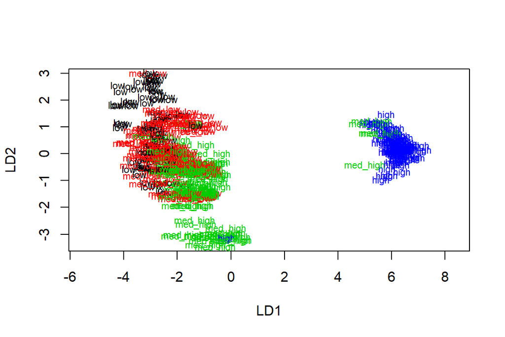

```r
# plot the lda results
classes <- as.numeric(train$crime)
plot(lda.fit, dimen = 2,col = classes,pch=classes)
```

- Predicting crime in the test data

We have saved the correct crime classes above. We now predict the crime class for each observation in the test data using our lda model, lda.fit. We also tabulate the prediction results with the true classes of the test data.

```r
# predict classes with test data
lda.pred <- predict(lda.fit, newdata = test)

# cross tabulate the results
table(correct = correct_classes, predicted = lda.pred$class)
```

```
##           predicted
## correct    low med_low med_high high
##   low       14      11        0    0
##   med_low    4      21        3    0
##   med_high   0      12       10    1
##   high       0       0        0   26
```

- Kmeans clustering of Boston dataset

As seen blow, we reload the Boston dataset, and standardize the dataset. Then calculate distance between the observations. We then run kmeans with k=3 first, then we investigate the optimal k and run the algorithm again.

```r
library(ggplot2)

data('Boston')
boston_scaled <- scale(Boston)

# euclidean distance matrix
dist_eu <- dist(boston_scaled)
summary(dist_eu)
```

```
##    Min. 1st Qu.  Median    Mean 3rd Qu.    Max.
##  0.1343  3.4620  4.8240  4.9110  6.1860 14.4000
```

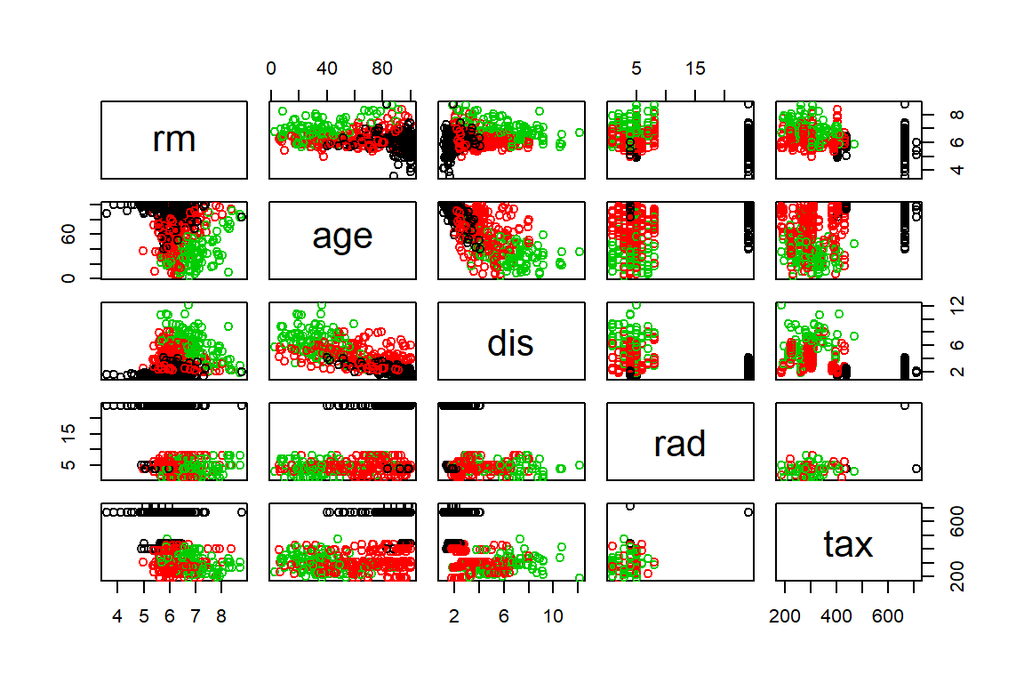

```r
# k-means clustering
km <-kmeans(boston_scaled, centers = 3)

pairs(Boston[6:10], col = km$cluster)
```

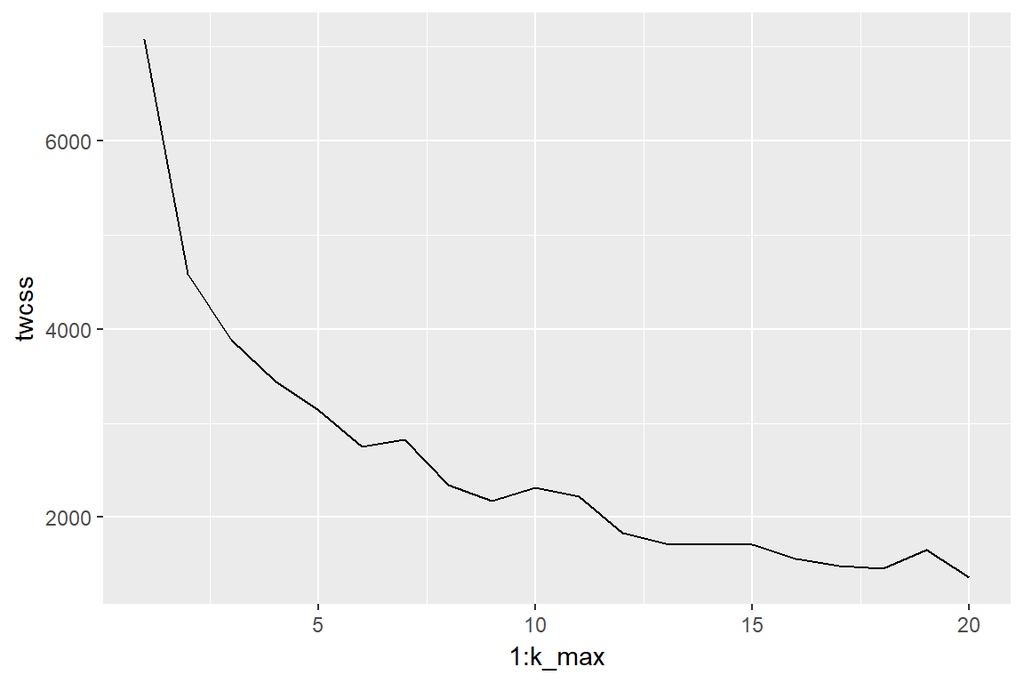

```r
# determine the number of clusters
k_max <- 20

# calculate the total within sum of squares
twcss <- sapply(1:k_max, function(k){kmeans(boston_scaled, k)$tot.withinss})

# visualize the results
qplot(x = 1:k_max, y = twcss, geom = 'line')
```

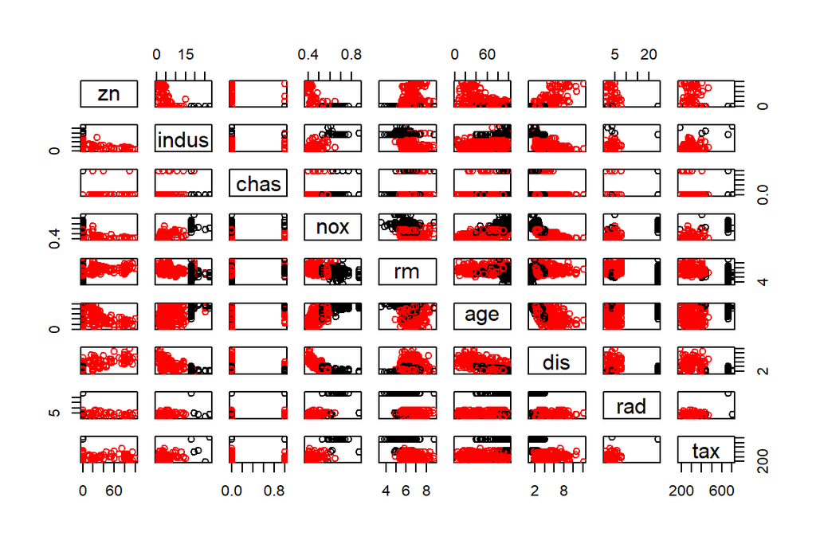

```r
# k-means clustering
km2 <-kmeans(boston_scaled, centers = 2)
pairs(Boston[2:10], col = km2$cluster)
```

The analysis on the scaled Boston data did not find an optimal k that’s different from what we saw in the datacamp exercise. The drastic drop in total within sum of squares still happens around k=2 or K=3, even though the decrease continues gradually and appears to stabilize around k=10. For now we used k=2 as the optimal k and rerun kmeans. K around 10 could also be an ideal choice, and can be investigated further in real research situations. Using the pairs function, we also did scatter plots between pairs of variables, the observations are colored according to the clusters they belong to. The scatter plots do not show clear, separate clusters even though they appear to make sense in some scatters (e.g nox vs rm plot)

- Bonus

To perfom LDA on the Boston dataset using k-means assigned cluster labels as the target variable, we first run kmeans on the scaled data (boston_scaled) using k = 3, then add the clustering results as categorical variable to the data. Then we fit LDA with the clustering results as the target variable.

```r
set.seed(42)
# k-means clustering, for stable clustering result, set iter.max and nstart higher.
km2 <-kmeans(boston_scaled, centers = 3,iter.max=30,nstart=10)

boston_scaled <- data.frame(boston_scaled, clusterLabel=km2$cluster)

# linear discriminant analysis
lda.fitkmClusters <- lda(clusterLabel ~ . , data = boston_scaled)
lda.fitkmClusters
```

```
## Call:
## lda(clusterLabel ~ ., data = boston_scaled)
##
## Prior probabilities of groups:
##         1         2         3
## 0.4664032 0.3241107 0.2094862
##
## Group means:
##         crim         zn     indus        chas        nox          rm
## 1 -0.3760908 -0.3417123 -0.296848  0.01127561 -0.3345884 -0.09228038
## 2  0.8046456 -0.4872402  1.117990  0.01575144  1.1253988 -0.46443119
## 3 -0.4075892  1.5146367 -1.068814 -0.04947434 -0.9962503  0.92400834
##           age         dis        rad        tax     ptratio      black
## 1 -0.02966623  0.05695857 -0.5803944 -0.6030198 -0.08691245  0.2863040
## 2  0.79737580 -0.85425848  1.2219249  1.2954050  0.60580719 -0.6407268
## 3 -1.16762641  1.19486951 -0.5983266 -0.6616391 -0.74378342  0.3538816
##        lstat        medv
## 1 -0.1801190  0.03577844
## 2  0.8719904 -0.68418954
## 3 -0.9480974  0.97889973
##
## Coefficients of linear discriminants:
##                 LD1         LD2
## crim    -0.03134296  0.14880455
## zn      -0.06381527  1.22350515
## indus    0.61086696  0.10402980
## chas     0.01953161 -0.03579238
## nox      1.00230143  0.70464917
## rm      -0.16285767  0.44390394
## age     -0.07220634 -0.59785382
## dis     -0.04270475  0.45498614
## rad      0.71987743  0.02882054
## tax      0.98285440  0.70663319
## ptratio  0.22527977  0.15514668
## black   -0.01693595 -0.03181845
## lstat    0.18274033  0.50122677
## medv    -0.02892966  0.64244841
##
## Proportion of trace:
##    LD1    LD2
## 0.8409 0.1591
```

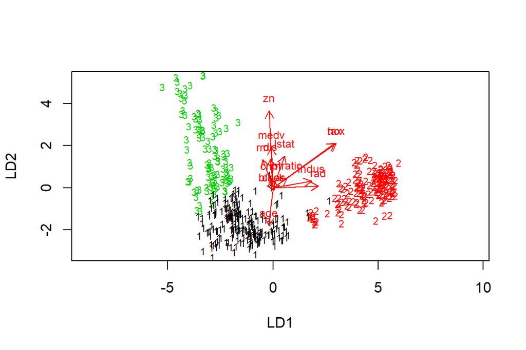

```r
# the function for lda biplot arrows: function copied from datacamp exercise
lda.arrows <- function(x, myscale = 1, arrow_heads = 0.1, color = "red", tex = 0.75, choices = c(1,2)){
  heads <- coef(x)
  arrows(x0 = 0, y0 = 0,
         x1 = myscale * heads[,choices[1]],
         y1 = myscale * heads[,choices[2]], col=color, length = arrow_heads)
  text(myscale * heads[,choices], labels = row.names(heads),
       cex = tex, col=color, pos=3)
}

# plot the lda results
plot(lda.fitkmClusters, dimen = 2,col = boston_scaled$clusterLabel)
lda.arrows(lda.fitkmClusters, myscale = 3)
```

As can be seen from the arrows on the biplot, the variable age seems to be highly influential separator for cluster 1, and tax, indus and rad for cluster 2. variables rm and zn look most influential in the separation of cluster 3.

#### Data wrangling to get the ‘human’ data

The data wrangling work for next week data has been done. The details of how this was done including the R commands used can be found in (https://github.com/Dawit2010/IODS-project/blob/master/data/create_human.R). The human dataset after the data wrangling can be found (https://github.com/Dawit2010/IODS-project/blob/master/data/human.txt)

# Chapter 5

## Dimensionality reduction techniques

In this chapter, we have looked at dimensionality reduction using PCA and MCA.

#### Dimensionality reduction using PCA

- Loading the human data We first load the human data containing Human development and gender inequality data for each country (original data obtained from : http://hdr.undp.org/en/content/human-development-index-hdi). The data combines several indicator variables of human development and gender inequality from 155 countries in the world. This data contains 155 observations (countries) and 8 variables (indicators) for each observation.

```r
human <- read.table("data/human.txt",header=T, sep="\t")
str(human)
```

```
## 'data.frame':    155 obs. of  8 variables:
##  $ SecondaryEducFtoM     : num  1.007 0.997 0.983 0.989 0.969 ...
##  $ LFPRFtoM              : num  0.891 0.819 0.825 0.884 0.829 ...
##  $ ExpEduInYears         : num  17.5 20.2 15.8 18.7 17.9 16.5 18.6 16.5 15.9 19.2 ...
##  $ LifeExpectancy        : num  81.6 82.4 83 80.2 81.6 80.9 80.9 79.1 82 81.8 ...
##  $ GNIperCapita          : int  64992 42261 56431 44025 45435 43919 39568 52947 42155 32689 ...
##  $ MaternalMortalityRatio: int  4 6 6 5 6 7 9 28 11 8 ...
##  $ AdolescentBirthRate   : num  7.8 12.1 1.9 5.1 6.2 3.8 8.2 31 14.5 25.3 ...
##  $ percentInParliament   : num  39.6 30.5 28.5 38 36.9 36.9 19.9 19.4 28.2 31.4 ...
```

- Overview of the human data

```r
summary(human)
```

```
##  SecondaryEducFtoM    LFPRFtoM      ExpEduInYears   LifeExpectancy
##  Min.   :0.1717    Min.   :0.1857   Min.   : 5.40   Min.   :49.00
##  1st Qu.:0.7264    1st Qu.:0.5984   1st Qu.:11.25   1st Qu.:66.30
##  Median :0.9375    Median :0.7535   Median :13.50   Median :74.20
##  Mean   :0.8529    Mean   :0.7074   Mean   :13.18   Mean   :71.65
##  3rd Qu.:0.9968    3rd Qu.:0.8535   3rd Qu.:15.20   3rd Qu.:77.25
##  Max.   :1.4967    Max.   :1.0380   Max.   :20.20   Max.   :83.50
##   GNIperCapita    MaternalMortalityRatio AdolescentBirthRate
##  Min.   :   581   Min.   :   1.0         Min.   :  0.60
##  1st Qu.:  4198   1st Qu.:  11.5         1st Qu.: 12.65
##  Median : 12040   Median :  49.0         Median : 33.60
##  Mean   : 17628   Mean   : 149.1         Mean   : 47.16
##  3rd Qu.: 24512   3rd Qu.: 190.0         3rd Qu.: 71.95
##  Max.   :123124   Max.   :1100.0         Max.   :204.80
##  percentInParliament
##  Min.   : 0.00
##  1st Qu.:12.40
##  Median :19.30
##  Mean   :20.91
##  3rd Qu.:27.95
##  Max.   :57.50
```

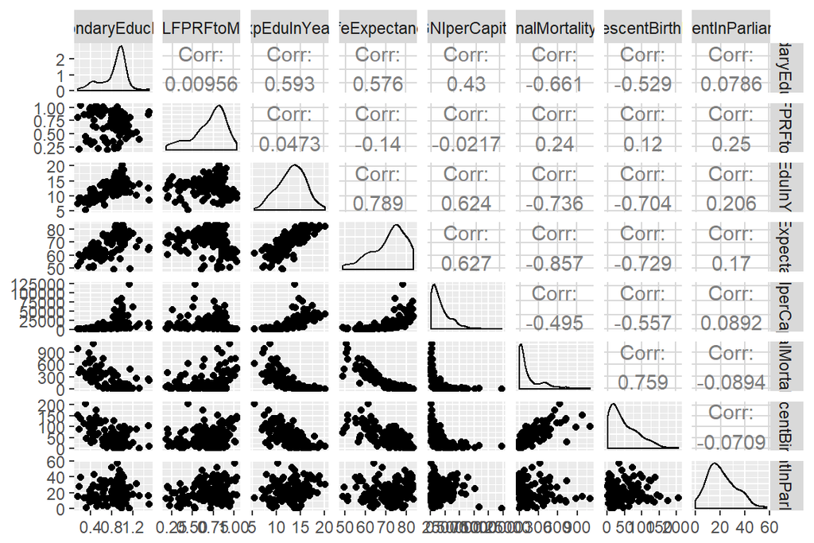

```r
library(GGally)

ggpairs(human)
```

The mean and range of each variables across the 155 countries can be seen using summary(human). The mean GNI per capita is 17628. Mean percentage of women in parlament is approx. 21%, which is much lower than the expected 50%. As can be seen from the correlations indicated above, there is a strong negative correlation between maternal mortality rate and life expectancy, and the strongest positive correlation is observed between expected education in years and life expectancy.

- perfrom PCA

We first perform PCA on the not standardized human data. As can be seen in the summary output, the first principal component PC1 captures more than 99% of the variability in the data. PC1 and PC2 combined capture 100% of the variability.

```r
pcaNS_human <- prcomp(human)
summary(pcaNS_human)
```

```
## Importance of components:
##                              PC1      PC2   PC3   PC4   PC5   PC6    PC7
## Standard deviation     1.854e+04 185.5219 25.19 11.45 3.766 1.566 0.1912
## Proportion of Variance 9.999e-01   0.0001  0.00  0.00 0.000 0.000 0.0000
## Cumulative Proportion  9.999e-01   1.0000  1.00  1.00 1.000 1.000 1.0000
##                           PC8
## Standard deviation     0.1591
## Proportion of Variance 0.0000
## Cumulative Proportion  1.0000
```

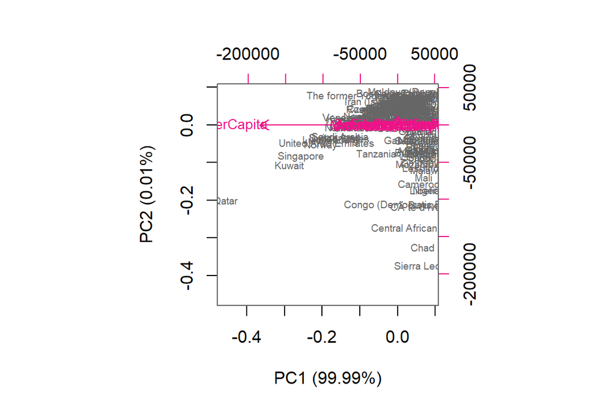

HumanPCA.1: PCA using non-standardized human data clusters countries mostly by PC1 which captures variation mostly from GNI per capita

```r
pca_pr <- round(100*summary(pcaNS_human)$importance[2, ], digits = 5)
pc_lab <- paste0(names(pca_pr), " (", pca_pr, "%)")

biplot(pcaNS_human, choices = 1:2,cex = c(0.6, 0.8),col = c("grey40", "deeppink2"),xlab = pc_lab[1], ylab = pc_lab[2])
```

As can be seen from the biplot of the pca above, the GNI per capita variable has a strong influence on PC1. It’s very possible that most of the variation is coming from this variable because of scaling differences between variables, with GNI per capita having high variation and range and thus affecting the PCA and biasing the result.

Next we perform PCA on the standardized human data set.

```r
human_std <- scale(human)
summary(human_std)
```

```
##  SecondaryEducFtoM    LFPRFtoM       ExpEduInYears     LifeExpectancy
##  Min.   :-2.8189   Min.   :-2.6247   Min.   :-2.7378   Min.   :-2.7188
##  1st Qu.:-0.5233   1st Qu.:-0.5484   1st Qu.:-0.6782   1st Qu.:-0.6425
##  Median : 0.3503   Median : 0.2316   Median : 0.1140   Median : 0.3056
##  Mean   : 0.0000   Mean   : 0.0000   Mean   : 0.0000   Mean   : 0.0000
##  3rd Qu.: 0.5958   3rd Qu.: 0.7350   3rd Qu.: 0.7126   3rd Qu.: 0.6717
##  Max.   : 2.6646   Max.   : 1.6632   Max.   : 2.4730   Max.   : 1.4218
##   GNIperCapita     MaternalMortalityRatio AdolescentBirthRate
##  Min.   :-0.9193   Min.   :-0.6992        Min.   :-1.1325
##  1st Qu.:-0.7243   1st Qu.:-0.6496        1st Qu.:-0.8394
##  Median :-0.3013   Median :-0.4726        Median :-0.3298
##  Mean   : 0.0000   Mean   : 0.0000        Mean   : 0.0000
##  3rd Qu.: 0.3712   3rd Qu.: 0.1932        3rd Qu.: 0.6030
##  Max.   : 5.6890   Max.   : 4.4899        Max.   : 3.8344
##  percentInParliament
##  Min.   :-1.8203
##  1st Qu.:-0.7409
##  Median :-0.1403
##  Mean   : 0.0000
##  3rd Qu.: 0.6127
##  Max.   : 3.1850
```

```r
pca_human <- prcomp(human_std)
summary(pca_human)
```

```
## Importance of components:
##                           PC1    PC2     PC3     PC4     PC5     PC6
## Standard deviation     2.0708 1.1397 0.87505 0.77886 0.66196 0.53631
## Proportion of Variance 0.5361 0.1624 0.09571 0.07583 0.05477 0.03595
## Cumulative Proportion  0.5361 0.6984 0.79413 0.86996 0.92473 0.96069
##                            PC7     PC8
## Standard deviation     0.45900 0.32224
## Proportion of Variance 0.02634 0.01298
## Cumulative Proportion  0.98702 1.00000
```

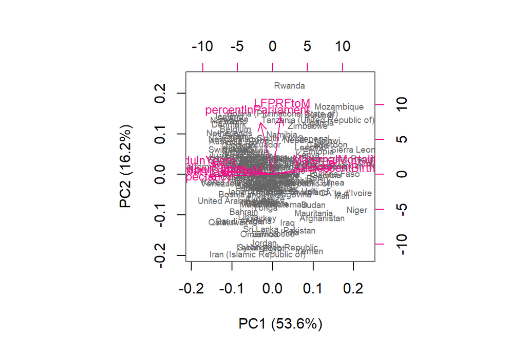

HumanPCA.2: PCA using standardized human data utilizes most variables and captures the real variation in the data instead of bias coming form few variables.In the biplot, countries with similar human development and gender inequality performance cluster together.

```r
pca_pr <- round(100*summary(pca_human)$importance[2, ], digits = 1)
pc_lab <- paste0(names(pca_pr), " (", pca_pr, "%)")

biplot(pca_human, choices = 1:2,cex = c(0.6, 0.8),col = c("grey40", "deeppink2"),xlab = pc_lab[1], ylab = pc_lab[2])
```

After performing PCA with the standardized human data (see above), PC1 captures 53.6% and PC2 captures 16.24% of the variablity in the data. The variablity captured by other principal components can be seen from the summary output above. PC1 and PC2 together capture 69.8% of the variability in the data. A biplot using PC1 and PC2 is also shown, with arrow direction indicating the variables that are contributing to the components. The PCA result obtained form the standardized human data is the proper way to do the analysis since we standardized all variables to the same scale, which allows PCA to work with the real variability in the data. When using data that is not standardized to the same scale, variables that have high range due to simply their measurement scale, will dominate the PCA resulting in wrong interpretation.

- Interpretation of PC1 and PC2 on standardized human data A number of insight can be gathered from HumanPCA.2. Expected years of education, life expectancy, GNI per capita, maternal mortality rate, adolescent birth rate are variables that contribute to PC1.countries with high expected years of education, life expectancy and GNI per capita cluster together. We can see counties with the opposite trend clustering together on the right hand of the plot. We could see that variables of female to male labor market ratio, and percent of females in parlament contribute to PC2, with those countries having higher female participation clustering in the top while those doing poorly in this regard clustering at the bottom. For example, Counties at the bottom-left could have good GNI,life expectancy etc but perform poorly in gender equality.
- Multiple Correspondence Analysis(MCA) on tea data

We first load the tea dataset from the FactoMineR package. The tea data has 300 observations with 36 variables. We select some variables (as was done in the datacamp exercise), and visualize them using a barplot. We then perform MCA on the tea data with the selected variables.

```r
library(FactoMineR);
library(dplyr);
library(tidyr);
library(ggplot2);

data("tea")

dim(tea)
```

```
## [1] 300  36
```

```r
str(tea)
```

```
## 'data.frame':    300 obs. of  36 variables:
##  $ breakfast       : Factor w/ 2 levels "breakfast","Not.breakfast": 1 1 2 2 1 2 1 2 1 1 ...
##  $ tea.time        : Factor w/ 2 levels "Not.tea time",..: 1 1 2 1 1 1 2 2 2 1 ...
##  $ evening         : Factor w/ 2 levels "evening","Not.evening": 2 2 1 2 1 2 2 1 2 1 ...
##  $ lunch           : Factor w/ 2 levels "lunch","Not.lunch": 2 2 2 2 2 2 2 2 2 2 ...
##  $ dinner          : Factor w/ 2 levels "dinner","Not.dinner": 2 2 1 1 2 1 2 2 2 2 ...
##  $ always          : Factor w/ 2 levels "always","Not.always": 2 2 2 2 1 2 2 2 2 2 ...
##  $ home            : Factor w/ 2 levels "home","Not.home": 1 1 1 1 1 1 1 1 1 1 ...
##  $ work            : Factor w/ 2 levels "Not.work","work": 1 1 2 1 1 1 1 1 1 1 ...
##  $ tearoom         : Factor w/ 2 levels "Not.tearoom",..: 1 1 1 1 1 1 1 1 1 2 ...
##  $ friends         : Factor w/ 2 levels "friends","Not.friends": 2 2 1 2 2 2 1 2 2 2 ...
##  $ resto           : Factor w/ 2 levels "Not.resto","resto": 1 1 2 1 1 1 1 1 1 1 ...
##  $ pub             : Factor w/ 2 levels "Not.pub","pub": 1 1 1 1 1 1 1 1 1 1 ...
##  $ Tea             : Factor w/ 3 levels "black","Earl Grey",..: 1 1 2 2 2 2 2 1 2 1 ...
##  $ How             : Factor w/ 4 levels "alone","lemon",..: 1 3 1 1 1 1 1 3 3 1 ...
```

[output cut: 22 more lines]

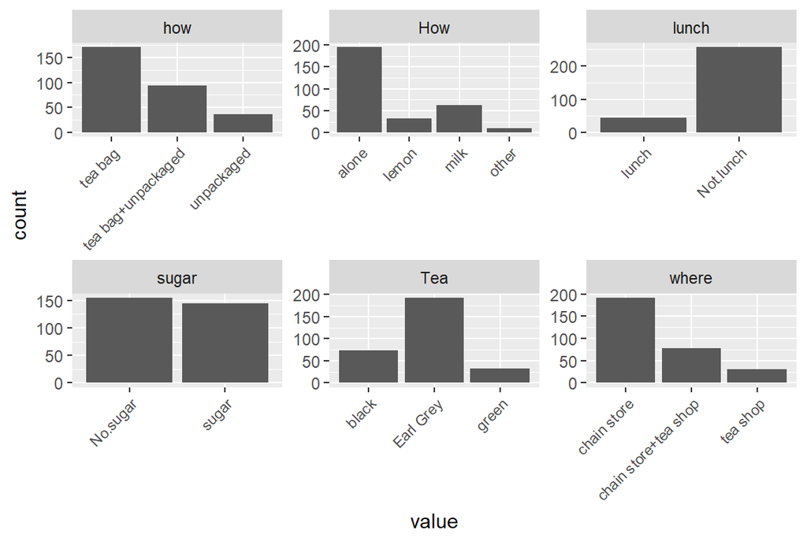

```r
# visualize the dataset using selected variables.
# column names to keep in the dataset
keep_columns <- c("Tea", "How", "how", "sugar", "where", "lunch")

# select the 'keep_columns' to create a new dataset
tea_time <- dplyr::select(tea, one_of(keep_columns))

gather(tea_time) %>% ggplot(aes(value)) + facet_wrap("key", scales = "free") + geom_bar() + theme(axis.text.x = element_text(angle = 45, hjust = 1, size = 8))
```

```r
# multiple correspondence analysis
mca <- MCA(tea_time, graph = FALSE)
summary(mca)
```

```
##
## Call:
## MCA(X = tea_time, graph = FALSE)
##
##
## Eigenvalues
##                        Dim.1   Dim.2   Dim.3   Dim.4   Dim.5   Dim.6
## Variance               0.279   0.261   0.219   0.189   0.177   0.156
## % of var.             15.238  14.232  11.964  10.333   9.667   8.519
## Cumulative % of var.  15.238  29.471  41.435  51.768  61.434  69.953
##                        Dim.7   Dim.8   Dim.9  Dim.10  Dim.11
## Variance               0.144   0.141   0.117   0.087   0.062
## % of var.              7.841   7.705   6.392   4.724   3.385
## Cumulative % of var.  77.794  85.500  91.891  96.615 100.000
##
## Individuals (the 10 first)
##                       Dim.1    ctr   cos2    Dim.2    ctr   cos2    Dim.3
## 1                  | -0.298  0.106  0.086 | -0.328  0.137  0.105 | -0.327
## 2                  | -0.237  0.067  0.036 | -0.136  0.024  0.012 | -0.695
## 3                  | -0.369  0.162  0.231 | -0.300  0.115  0.153 | -0.202
## 4                  | -0.530  0.335  0.460 | -0.318  0.129  0.166 |  0.211
## 5                  | -0.369  0.162  0.231 | -0.300  0.115  0.153 | -0.202
## 6                  | -0.369  0.162  0.231 | -0.300  0.115  0.153 | -0.202
## 7                  | -0.369  0.162  0.231 | -0.300  0.115  0.153 | -0.202
## 8                  | -0.237  0.067  0.036 | -0.136  0.024  0.012 | -0.695
## 9                  |  0.143  0.024  0.012 |  0.871  0.969  0.435 | -0.067
## 10                 |  0.476  0.271  0.140 |  0.687  0.604  0.291 | -0.650
##                       ctr   cos2
## 1                   0.163  0.104 |
## 2                   0.735  0.314 |
## 3                   0.062  0.069 |
## 4                   0.068  0.073 |
## 5                   0.062  0.069 |
## 6                   0.062  0.069 |
## 7                   0.062  0.069 |
## 8                   0.735  0.314 |
## 9                   0.007  0.003 |
## 10                  0.643  0.261 |
##
## Categories (the 10 first)
```

[output cut: 16 more lines]

```
## lemon                0.035   3.226 |   1.329  14.771   0.218   8.081 |
## milk                 0.020   2.422 |   0.013   0.003   0.000   0.116 |
## other                0.102   5.534 |  -2.524  14.526   0.197  -7.676 |
## tea bag              0.161  -6.941 |  -0.065   0.183   0.006  -1.287 |
## tea bag+unpackaged   0.478  11.956 |   0.019   0.009   0.000   0.226 |
## unpackaged           0.141  -6.482 |   0.257   0.602   0.009   1.640 |
##
## Categorical variables (eta2)
##                      Dim.1 Dim.2 Dim.3
## Tea                | 0.126 0.108 0.410 |
## How                | 0.076 0.190 0.394 |
## how                | 0.708 0.522 0.010 |
## sugar              | 0.065 0.001 0.336 |
## where              | 0.702 0.681 0.055 |
## lunch              | 0.000 0.064 0.111 |
```

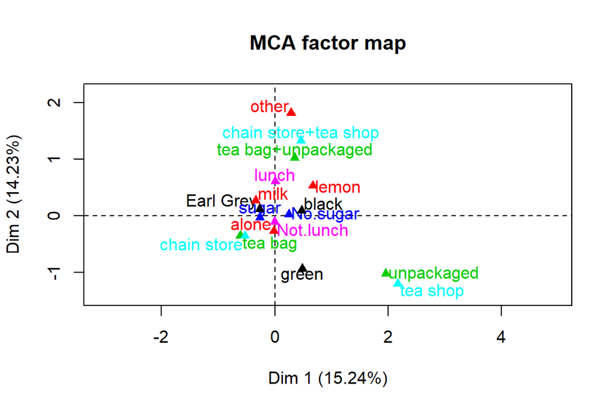

```r
plot(mca, invisible=c("ind"),habillage = "quali")
```

The cumulative percentage of variance explained by the first two MCA dimensions is 29.5%. We can see variable categories that are closer to each other in the mca biplot (each variable is colored differently, i.e variable categories of a variable are colored the same). For example,variable category earl grey appears closer with variable categories sugar and milk, indicating how it is drunk by the individuals in the tea data.